# Assignment 3

Authors

Max Heinze (maximilian.heinze@wu.ac.at)

Sannah Tijani (sannah.tijani@wu.ac.at)

Published

March 21, 2025

### Task

> Study the performance of the AIPW estimator with and without sample splitting numerically. In particular, choose your favorite method for estimating the $\mu_w(x)$ functions and your favorite method for estimating the propensity scores and study the performance of the corresponding estimator (with and withoug splitting) on simulated data. Illustrate how sample splitting affects the distribution of the estimator, and how “honest” is to be interpreted.

### Implementation

```r
# Load necessary libraries
library(randomForest)
library(ggplot2)
library(reshape2)
```

We begin by setting the parameters for simulating the data. We set:

- $X$ (the covariate) to be normally distributed,
- the propensity score $e(X_i)$ (`ps` in the code) to follow
  $$e(X_i) = \frac{1}{1 + \mathrm{exp}(-0.5X_i)},$$
  so that the values depend on $X_i$ and stay nicely between 0 and 1,
- the treatment $W_i$ to be Bernoulli distributed with the propensity score as treatment probability for each $i$,
- the real treatment effect $\tau$ to equal 1,
- $\mu_0 = 2 + \mathrm{sin}(X_i)$ in order to deliberately introduce nonlinearities,
- $\mu_1$ straightforwardly as $\mu_0$ plus treatment,
- random noise, and
- $Y_i$ as the sum of all of those, with $\mu_0$ used for non-treated observations and $\mu_1$ otherwise.

```r
# Define the expit (logistic) function
expit <- function(x) {
  1 / (1 + exp(-x))
}

# Function to simulate data
simulate_data <- function(n) {
  X <- rnorm(n, mean = 0, sd = 1)
  ps <- expit(0.5 * X)
  W <- rbinom(n, 1, ps)
  tau <- 1
  mu0 <- 2 + sin(X)
  mu1 <- mu0 + tau
  noise <- rnorm(n, mean = 0, sd = 1)
  Y <- ifelse(W == 0, mu0 + noise, mu1 + noise)
  data.frame(X = X, W = W, Y = Y, true_ps = ps, mu0 = mu0, mu1 = mu1, tau = tau)
}
```

Next, we define a function that estimates the AIPW estimator once on the full sample, and once using cross-fitting. Since the procedure is the same except for splitting the sample and estimating on the respective parts, we comment on it only once.

We start by estimating the propensity scores from the simulated data using logistic regression. Next, we use these scores to predict the propensity scores for each estimation and store them.

In a second step, we use random forest (separately for non-treated and treated observations) to estimate the $\mu_0$ and $\mu_1$ for each observation and store the predicted values. We use random forest since we can that way flexibly approximate non-linear relations like the present one.

We define a function for the AIPW estimator that follows the formula which we defined in the course:

$$\widehat{\tau}_{\text{AIPW}} = \frac{1}{n}\sum_{i=1}^{n} \left( \left(\hat{\mu}_1(X_i) - \hat{\mu}_0(X_i)\right) + \frac{W_i \left( Y_i - \hat{\mu}_1(X_i) \right)}{\hat{e}(X_i)} - (1-W_i)\frac{ \left( Y_i - \hat{\mu}_0(X_i) \right)}{1-\hat{e}(X_i)} \right),$$

and compute the estimate for the treatment effect with it.

```r
# AIPW estimator without sample splitting
estimate_aipw <- function(data) {
  # Estimate propensity scores using logistic regression
  ps_model <- glm(W ~ X, data = data, family = binomial)
  data$ps_hat <- predict(ps_model, type = "response")

  # Estimate outcome regression functions using random forest
  rf0 <- randomForest(Y ~ X, data = data[data$W == 0, ])
  rf1 <- randomForest(Y ~ X, data = data[data$W == 1, ])
  data$mu0_hat <- predict(rf0, newdata = data)
  data$mu1_hat <- predict(rf1, newdata = data)

  # Compute individual AIPW contributions
  aipw <- with(data, (W * (Y - mu1_hat) / ps_hat) - ((1 - W) * (Y - mu0_hat) / (1 - ps_hat)) + (mu1_hat - mu0_hat))
  mean(aipw)
}

# AIPW estimator with sample splitting
estimate_aipw_split <- function(data) {
  n <- nrow(data)
  train_idx <- sample(1:n, size = floor(n / 2), replace = FALSE)
  eval_idx <- setdiff(1:n, train_idx)
  train_data <- data[train_idx, ]
  eval_data <- data[eval_idx, ]

  # Estimate propensity scores on training data and predict on evaluation data
  ps_model <- glm(W ~ X, data = train_data, family = binomial)
  eval_data$ps_hat <- predict(ps_model, newdata = eval_data, type = "response")

  # Estimate outcome regressions on training data and predict on evaluation data
  rf0 <- randomForest(Y ~ X, data = train_data[train_data$W == 0, ])
  rf1 <- randomForest(Y ~ X, data = train_data[train_data$W == 1, ])
  eval_data$mu0_hat <- predict(rf0, newdata = eval_data)
  eval_data$mu1_hat <- predict(rf1, newdata = eval_data)

  # Compute AIPW estimator on evaluation data
  aipw <- with(eval_data, (W * (Y - mu1_hat) / ps_hat) - ((1 - W) * (Y - mu0_hat) / (1 - ps_hat)) + (mu1_hat - mu0_hat))
  mean(aipw)
}
```

Finally, we simulate a varying number of repetitions (100, 500, and 2000) and store the estimates. We then compute means and standard deviations and plot the distributions (code for plots, mean, and standard deviation is omitted for brevity).

```r
# Simulation settings
set.seed(123)    # For reproducibility
n_rep <- 2000     # Number of replications
n <- 1000        # Sample size per replication

estimates_no_split <- numeric(n_rep)
estimates_split <- numeric(n_rep)
true_tau <- 1

for (i in 1:n_rep) {
  data <- simulate_data(n)
  estimates_no_split[i] <- estimate_aipw(data)
  estimates_split[i] <- estimate_aipw_split(data)
}
```

### Results

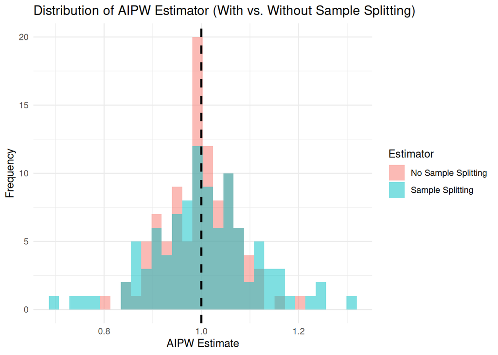

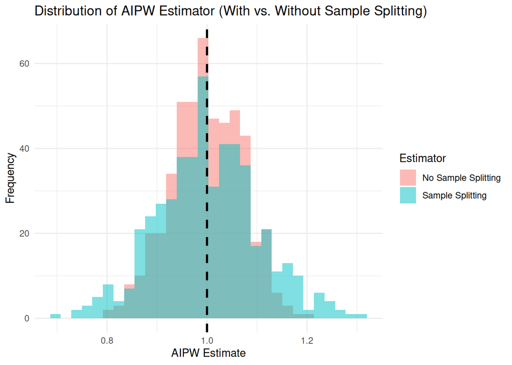

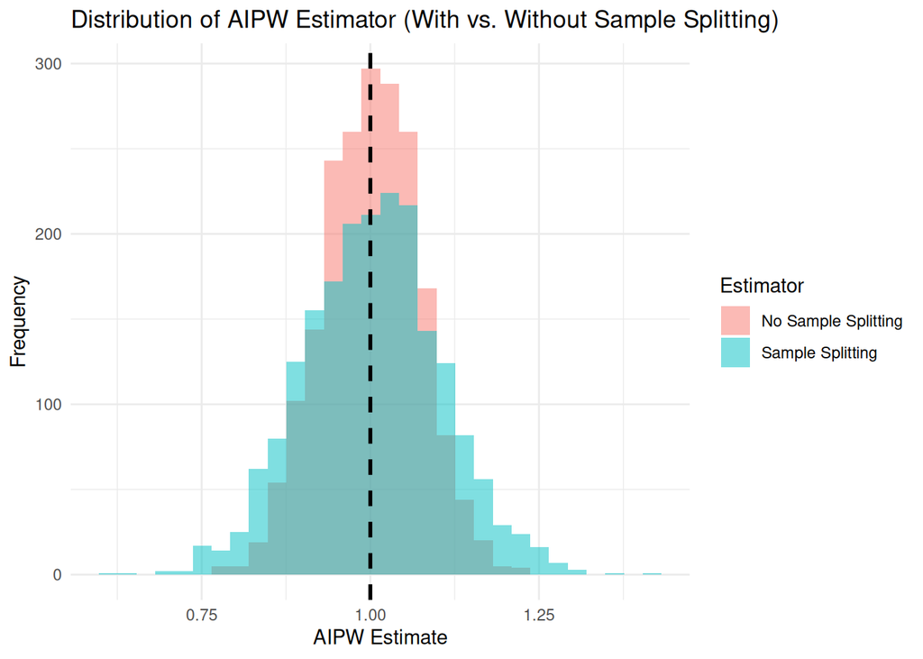

| **Repetitions** | **Mean Full** | **Mean Split** | **SD Full** | **SD Split** |
| --- | --- | --- | --- | --- |
| 100 | 0.996 | 1.003 | 0.071 | 0.107 |
| 500 | 0.999 | 1.002 | 0.071 | 0.101 |
| 2000 | 1.001 | 1.004 | 0.071 | 0.102 |